# EDA Overivew

One of the most important steps to any data science experiment is Exploratory Data Analysis (EDA). EDA provides a first look at the data and is a critical in analyzing the data to understand and summarize its content. This is important to ensure the features fed into a ML algorithms are refined in order to get valid, correctly interpreted results.

EDA can be non-graphical or graphical. Each method can be applied to one variable/column (univariate) or a combination of variables (bivariate, multivariate).

A first step in any data scicence experiment is to understand the problem statement and the data before creating a model. This helps for gaining insights that will inform modeling choice and decisions.

**The problem statement: Predict whether income exceeds $50K/yr based on census data. Also known as "Census Income" dataset.** .

Remainder of this notebook provides coding examples of EDA for census data.

### Load required libraries

```python
import numpy as np
import pandas as pd
import seaborn as sns
import matplotlib.pyplot as plt
```

### Reading the data

- Adult Dataset; the Cenus Income from the 1994 Census Database: https://archive.ics.uci.edu/ml/datasets/adult
- download link: https://archive.ics.uci.edu/ml/machine-learning-databases/adult/adult.data

**Data description**

- **age**: continuous.
- **workclass**: Private, Self-emp-not-inc, Self-emp-inc, Federal-gov, Local-gov, State-gov, Without-pay, Never-worked.
- **fnlwgt**: continuous
- **education**: Bachelors, Some-college, 11th, HS-grad, Prof-school, Assoc-acdm, Assoc-voc, 9th, 7th-8th, 12th, Masters, 1st-4th, 10th, Doctorate, 5th-6th, Preschool.
- **education-num**: continuous.
- **marital-status**: Married-civ-spouse, Divorced, Never-married, Separated, Widowed, Married-spouse-absent, Married-AF-spouse.
- **occupation**: Tech-support, Craft-repair, Other-service, Sales, Exec-managerial, Prof-specialty, Handlers-cleaners, Machine-op-inspct, Adm-clerical, Farming-fishing, Transport-moving, Priv-house-serv, Protective-serv, Armed-Forces.
- **relationship**: Wife, Own-child, Husband, Not-in-family, Other-relative, Unmarried.
- **race**: White, Asian-Pac-Islander, Amer-Indian-Eskimo, Other, Black.
- **sex**: Female, Male.
- **capital-gain**: continuous.
- **capital-loss**: continuous.
- **hours-per-week**: continuous.
- **native-country**: United-States, Cambodia, England, Puerto-Rico, Canada, Germany, Outlying-US(Guam-USVI-etc), India, Japan, Greece, South, China, Cuba, Iran, Honduras, Philippines, Italy, Poland, Jamaica, Vietnam, Mexico, Portugal, Ireland, France, Dominican-Republic, Laos, Ecuador, Taiwan, Haiti, Columbia, Hungary, Guatemala, Nicaragua, Scotland, Thailand, Yugoslavia, El-Salvador, Trinadad&Tobago, Peru, Hong, Holand-Netherlands.

```python
# data download url
url = "https://archive.ics.uci.edu/ml/machine-learning-databases/adult/adult.data"

# create columns
columns = ["age", "work-class", "fnlwgt", "education", "education-num","marital-status", "occupation", "relationship",
          "race", "sex", "capital-gain", "capital-loss", "hours-per-week", "native-country", "income"]

# create a dataframe, data loaded from url
data = pd.read_csv(url, names=columns, sep=',')
```

### Peak at the data

- show shape (eg: size, number of colums)
- show variable types
- display first few lines or last few lines to better understand the attributes

```python
# shape of the data
print (data.shape, '\n')

# get details of the data type for each variable
data.info()
```

```
(32561, 15)

<class 'pandas.core.frame.DataFrame'>
RangeIndex: 32561 entries, 0 to 32560
Data columns (total 15 columns):
 #   Column          Non-Null Count  Dtype
---  ------          --------------  -----
 0   age             32561 non-null  int64
 1   work-class      32561 non-null  object
 2   fnlwgt          32561 non-null  int64
 3   education       32561 non-null  object
 4   education-num   32561 non-null  int64
 5   marital-status  32561 non-null  object
 6   occupation      32561 non-null  object
 7   relationship    32561 non-null  object
 8   race            32561 non-null  object
 9   sex             32561 non-null  object
 10  capital-gain    32561 non-null  int64
 11  capital-loss    32561 non-null  int64
 12  hours-per-week  32561 non-null  int64
 13  native-country  32561 non-null  object
 14  income          32561 non-null  object
dtypes: int64(6), object(9)
memory usage: 3.7+ MB
```

- 32561 obvservations with 15 columns/variables
- DType of 'object' specifies non-continous (eg: discrete/categorical) variable

```python
# get numerical data only
numeric_data = data.select_dtypes(include=['int'])

numeric_data.info()
```

```
<class 'pandas.core.frame.DataFrame'>
RangeIndex: 32561 entries, 0 to 32560
Data columns (total 6 columns):
 #   Column          Non-Null Count  Dtype
---  ------          --------------  -----
 0   age             32561 non-null  int64
 1   fnlwgt          32561 non-null  int64
 2   education-num   32561 non-null  int64
 3   capital-gain    32561 non-null  int64
 4   capital-loss    32561 non-null  int64
 5   hours-per-week  32561 non-null  int64
dtypes: int64(6)
memory usage: 1.5 MB
```

```python
# get categorical data
cat_data = data.select_dtypes(include=['object'])

cat_data.info()
```

```
<class 'pandas.core.frame.DataFrame'>
RangeIndex: 32561 entries, 0 to 32560
Data columns (total 9 columns):
 #   Column          Non-Null Count  Dtype
---  ------          --------------  -----
 0   work-class      32561 non-null  object
 1   education       32561 non-null  object
 2   marital-status  32561 non-null  object
 3   occupation      32561 non-null  object
 4   relationship    32561 non-null  object
 5   race            32561 non-null  object
 6   sex             32561 non-null  object
 7   native-country  32561 non-null  object
 8   income          32561 non-null  object
dtypes: object(9)
memory usage: 2.2+ MB
```

```python
# show counts values of each categorical variable
for colname in cat_data.columns:
    print (colname)
    print (cat_data[colname].value_counts(), '\n')
```

```
work-class
 Private             22696
 Self-emp-not-inc     2541
 Local-gov            2093
 ?                    1836
 State-gov            1298
 Self-emp-inc         1116
 Federal-gov           960
 Without-pay            14
 Never-worked            7
Name: work-class, dtype: int64

education
 HS-grad         10501
 Some-college     7291
 Bachelors        5355
 Masters          1723
 Assoc-voc        1382
 11th             1175
 Assoc-acdm       1067
 10th              933
 7th-8th           646
 Prof-school       576
 9th               514
 12th              433
 Doctorate         413
 5th-6th           333
 1st-4th           168
 Preschool          51
Name: education, dtype: int64

marital-status
 Married-civ-spouse       14976
 Never-married            10683
 Divorced                  4443
 Separated                 1025
 Widowed                    993
 Married-spouse-absent      418
 Married-AF-spouse           23
Name: marital-status, dtype: int64
```

[output cut: 75 more lines]

```
 Trinadad&Tobago                  19
 Thailand                         18
 Laos                             18
 Yugoslavia                       16
 Outlying-US(Guam-USVI-etc)       14
 Honduras                         13
 Hungary                          13
 Scotland                         12
 Holand-Netherlands                1
Name: native-country, dtype: int64

income
 <=50K    24720
 >50K      7841
Name: income, dtype: int64
```

We can see some categories have many levels (eg: education, occupation, native-country)  
These can potentially be combined to reduce the number of values (see data preprocessing later)

```python
# first 5 lines of the dataset. (you can specify how many lines by providing an int parameter )
data.head()
```

|  | age | work-class | fnlwgt | education | education-num | marital-status | occupation | relationship | race | sex | capital-gain | capital-loss | hours-per-week | native-country | income |
| --- | --- | --- | --- | --- | --- | --- | --- | --- | --- | --- | --- | --- | --- | --- | --- |
| 0 | 39 | State-gov | 77516 | Bachelors | 13 | Never-married | Adm-clerical | Not-in-family | White | Male | 2174 | 0 | 40 | United-States | <=50K |
| 1 | 50 | Self-emp-not-inc | 83311 | Bachelors | 13 | Married-civ-spouse | Exec-managerial | Husband | White | Male | 0 | 0 | 13 | United-States | <=50K |
| 2 | 38 | Private | 215646 | HS-grad | 9 | Divorced | Handlers-cleaners | Not-in-family | White | Male | 0 | 0 | 40 | United-States | <=50K |
| 3 | 53 | Private | 234721 | 11th | 7 | Married-civ-spouse | Handlers-cleaners | Husband | Black | Male | 0 | 0 | 40 | United-States | <=50K |
| 4 | 28 | Private | 338409 | Bachelors | 13 | Married-civ-spouse | Prof-specialty | Wife | Black | Female | 0 | 0 | 40 | Cuba | <=50K |

```python
# last several lines the dataset, specifying number of lines, or leave it out for 5 lines
data.tail(3)
```

|  | age | work-class | fnlwgt | education | education-num | marital-status | occupation | relationship | race | sex | capital-gain | capital-loss | hours-per-week | native-country | income |
| --- | --- | --- | --- | --- | --- | --- | --- | --- | --- | --- | --- | --- | --- | --- | --- |
| 32558 | 58 | Private | 151910 | HS-grad | 9 | Widowed | Adm-clerical | Unmarried | White | Female | 0 | 0 | 40 | United-States | <=50K |
| 32559 | 22 | Private | 201490 | HS-grad | 9 | Never-married | Adm-clerical | Own-child | White | Male | 0 | 0 | 20 | United-States | <=50K |
| 32560 | 52 | Self-emp-inc | 287927 | HS-grad | 9 | Married-civ-spouse | Exec-managerial | Wife | White | Female | 15024 | 0 | 40 | United-States | >50K |

## Preprocessing and cleansing

Data preprocessing is a critical step in ML as the quality of data and the useful information derived from it directly affects the ability of our model to learn. These include the following:

- **Handling Null/Missing Values**: easiest way is to remove all missing values, however it's not always the best approach as you could be losing valuable information that impacts your model, especially if your dataset is small.

  ```
    ** ways to handle missing data **
    - Drop these rows to exclude missing values in the data
    - Replace with median/mean of values. Median may be better as it's unaffected by range/spread of data
  ```

- **Standardization**: Creates a normalized scale for variables which are very different in scale. We transform values so the mean of the values is 0 and the standard deviation is 1. For example: given weight (kg) and age (years), if we don't standardize their values, weight will be given more weight/importance in our model given weight is much greater than age.
- **Handling Categorical Variables**: Categorical variables have discreet values vs continous/numeric values. Often categories contain descriptions for values; eg: gender (male/female) or size (XL/L/M/S/XM). size is ordinal (it has an order (XL > L > S > XS), while gender is nominal (there is no order). To feed these types of categorial features into a model, requires they be converted to numeric representations using dummy-encoding, one-hot encoding, etc. The correct method to apply depends on whether it's nominal or ordinal.
- **Data Quality**: To check for data quality issues, you can sample your data. For categorical variables, look at the range of possible values to ensure they make sense. If there are outliers, decide if they can be dropped depending on the nature of the outlier. They may be legitiate observatons and are sometimes the most interesting ones.

  ```
  ** ways to handle outliers **
  - drop if the outlier is a mistake (eg: data entry)
  - drop if the outlier creates a significant association that doesn't otherwise exist
  - drop, if you have a lot of data and your sample won’t be hurt by dropping a questionable outlier<br>

  ** simplify the data for use in modeling **
  - Categorical variable with many levels (eg: many categories), decide whether some levels can be combined
  - For multiple fields representing the same data, decide if one can be dropped or combined into a new field
  ```

**Checking data quality**

- education-num vs education column: should we just keep 1?
- capital-gain and capital-loss: we can sum up these into a new column "capital-gain-total" ?
- education: we could combine some levels to reduce the number of categories
- marital-status: similar to education, we could combine some categories to reduce the number
- occupation: like education, we can combine some categories
- working-class: like education, we can combine some
- native-country: like education, we can combine some

```python
# show unique values for education
data['education'].unique()
```

```
array([' Bachelors', ' HS-grad', ' 11th', ' Masters', ' 9th',
       ' Some-college', ' Assoc-acdm', ' Assoc-voc', ' 7th-8th',
       ' Doctorate', ' Prof-school', ' 5th-6th', ' 10th', ' 1st-4th',
       ' Preschool', ' 12th'], dtype=object)
```

Observe leading spaces in values for education. Lets check all categorical values

```python
# show counts values of each categorical variable
for colname in cat_data.columns:
    print (colname)
    print (cat_data[colname].unique(), '\n')
```

```
work-class
[' State-gov' ' Self-emp-not-inc' ' Private' ' Federal-gov' ' Local-gov'
 ' ?' ' Self-emp-inc' ' Without-pay' ' Never-worked']

education
[' Bachelors' ' HS-grad' ' 11th' ' Masters' ' 9th' ' Some-college'
 ' Assoc-acdm' ' Assoc-voc' ' 7th-8th' ' Doctorate' ' Prof-school'
 ' 5th-6th' ' 10th' ' 1st-4th' ' Preschool' ' 12th']

marital-status
[' Never-married' ' Married-civ-spouse' ' Divorced'
 ' Married-spouse-absent' ' Separated' ' Married-AF-spouse' ' Widowed']

occupation
[' Adm-clerical' ' Exec-managerial' ' Handlers-cleaners' ' Prof-specialty'
 ' Other-service' ' Sales' ' Craft-repair' ' Transport-moving'
 ' Farming-fishing' ' Machine-op-inspct' ' Tech-support' ' ?'
 ' Protective-serv' ' Armed-Forces' ' Priv-house-serv']

relationship
[' Not-in-family' ' Husband' ' Wife' ' Own-child' ' Unmarried'
 ' Other-relative']

race
[' White' ' Black' ' Asian-Pac-Islander' ' Amer-Indian-Eskimo' ' Other']

sex
[' Male' ' Female']

native-country
[' United-States' ' Cuba' ' Jamaica' ' India' ' ?' ' Mexico' ' South'
 ' Puerto-Rico' ' Honduras' ' England' ' Canada' ' Germany' ' Iran'
 ' Philippines' ' Italy' ' Poland' ' Columbia' ' Cambodia' ' Thailand'
 ' Ecuador' ' Laos' ' Taiwan' ' Haiti' ' Portugal' ' Dominican-Republic'
 ' El-Salvador' ' France' ' Guatemala' ' China' ' Japan' ' Yugoslavia'
 ' Peru' ' Outlying-US(Guam-USVI-etc)' ' Scotland' ' Trinadad&Tobago'
 ' Greece' ' Nicaragua' ' Vietnam' ' Hong' ' Ireland' ' Hungary'
 ' Holand-Netherlands']

income
[' <=50K' ' >50K']
```

Most of these have leading spaces, clean these up by stripping leading/trailing spaces

```python
# Cleanup by strip leading/trailing spaces
data[cat_data.columns] = cat_data.apply(lambda x: x.str.strip())

# verify
cat_data = data.select_dtypes(include=['object'])
for colname in cat_data.columns:
    print (colname)
    print (cat_data[colname].unique(), '\n')
```

```
work-class
['State-gov' 'Self-emp-not-inc' 'Private' 'Federal-gov' 'Local-gov' '?'
 'Self-emp-inc' 'Without-pay' 'Never-worked']

education
['Bachelors' 'HS-grad' '11th' 'Masters' '9th' 'Some-college' 'Assoc-acdm'
 'Assoc-voc' '7th-8th' 'Doctorate' 'Prof-school' '5th-6th' '10th'
 '1st-4th' 'Preschool' '12th']

marital-status
['Never-married' 'Married-civ-spouse' 'Divorced' 'Married-spouse-absent'
 'Separated' 'Married-AF-spouse' 'Widowed']

occupation
['Adm-clerical' 'Exec-managerial' 'Handlers-cleaners' 'Prof-specialty'
 'Other-service' 'Sales' 'Craft-repair' 'Transport-moving'
 'Farming-fishing' 'Machine-op-inspct' 'Tech-support' '?'
 'Protective-serv' 'Armed-Forces' 'Priv-house-serv']

relationship
['Not-in-family' 'Husband' 'Wife' 'Own-child' 'Unmarried' 'Other-relative']

race
['White' 'Black' 'Asian-Pac-Islander' 'Amer-Indian-Eskimo' 'Other']

sex
['Male' 'Female']

native-country
['United-States' 'Cuba' 'Jamaica' 'India' '?' 'Mexico' 'South'
 'Puerto-Rico' 'Honduras' 'England' 'Canada' 'Germany' 'Iran'
 'Philippines' 'Italy' 'Poland' 'Columbia' 'Cambodia' 'Thailand' 'Ecuador'
 'Laos' 'Taiwan' 'Haiti' 'Portugal' 'Dominican-Republic' 'El-Salvador'
 'France' 'Guatemala' 'China' 'Japan' 'Yugoslavia' 'Peru'
 'Outlying-US(Guam-USVI-etc)' 'Scotland' 'Trinadad&Tobago' 'Greece'
 'Nicaragua' 'Vietnam' 'Hong' 'Ireland' 'Hungary' 'Holand-Netherlands']

income
['<=50K' '>50K']
```

When the number of categories are large, they aren't as helpful, so we can reduce by combining categories into groupings. For education, I will reduce the number of categories.

```python
#data2 = data.copy()
data['education'].replace('Preschool', 'LessHS', inplace=True)

data['education'].replace('10th', 'LessHS',inplace=True)
data['education'].replace('11th', 'LessHS',inplace=True)
data['education'].replace('12th', 'LessHS',inplace=True)
data['education'].replace('1st-4th', 'LessHS',inplace=True)
data['education'].replace('5th-6th', 'LessHS',inplace=True)
data['education'].replace('7th-8th', 'LessHS',inplace=True)
data['education'].replace('9th', 'LessHS',inplace=True)
data['education'].replace('Assoc-acdm', 'Some-college',inplace=True)
data['education'].replace('Assoc-voc', 'Some-college',inplace=True)
data['education'].replace('Prof-school', 'Masters',inplace=True)

data['education'].unique()
```

```
array(['Bachelors', 'HS-grad', 'LessHS', 'Masters', 'Some-college',
       'Doctorate'], dtype=object)
```

captial-gain and capital-loss are related. We can these into 1 column: netcapitalgain, then drop the old ones

```python
data['netcapitalgain'] = data.apply(lambda x: x['capital-gain'] + x['capital-loss'], axis=1)
data = data.drop(columns='capital-gain')
data = data.drop(columns='capital-loss')
```

**Checking for NULL/Missing values**

```python
# determins if there are any nulls
print (data.isnull().values.any(), '\n\ncount of nulls')

# count number of nulls
print ( data.isnull().sum())
```

```
False

count of nulls
age               0
work-class        0
fnlwgt            0
education         0
education-num     0
marital-status    0
occupation        0
relationship      0
race              0
sex               0
hours-per-week    0
native-country    0
income            0
netcapitalgain    0
dtype: int64
```

- There are no missing values
- We can also check for missing values by column

```python
# missing values by columns
print("Missing value counts for occupation: ", data['occupation'].isnull().sum())
```

```
Missing value counts for occupation:  0
```

There are no missing values but if there were, we could decide to drop all of them (depending on analysis of consequences of doing so) as follows.

```python
# if there were missing values we can drop them if we decided
data = data.dropna()
```

**Checking for duplicate values**

```python
# check duplicates across all rows

duplicateRows = data[data.duplicated()]
print('duplicates size: ', len(duplicateRows ))
duplicateRows.head()
```

```
duplicates size:  24
```

|  | age | work-class | fnlwgt | education | education-num | marital-status | occupation | relationship | race | sex | hours-per-week | native-country | income | netcapitalgain |
| --- | --- | --- | --- | --- | --- | --- | --- | --- | --- | --- | --- | --- | --- | --- |
| 4881 | 25 | Private | 308144 | Bachelors | 13 | Never-married | Craft-repair | Not-in-family | White | Male | 40 | Mexico | <=50K | 0 |
| 5104 | 90 | Private | 52386 | Some-college | 10 | Never-married | Other-service | Not-in-family | Asian-Pac-Islander | Male | 35 | United-States | <=50K | 0 |
| 9171 | 21 | Private | 250051 | Some-college | 10 | Never-married | Prof-specialty | Own-child | White | Female | 10 | United-States | <=50K | 0 |
| 11631 | 20 | Private | 107658 | Some-college | 10 | Never-married | Tech-support | Not-in-family | White | Female | 10 | United-States | <=50K | 0 |
| 13084 | 25 | Private | 195994 | LessHS | 2 | Never-married | Priv-house-serv | Not-in-family | White | Female | 40 | Guatemala | <=50K | 0 |

```python
# check duplicates for a specific columns

duplicateRows = data[data.duplicated(['age', 'marital-status'])]
duplicateRows.sort_values(by=['age']).head()
```

|  | age | work-class | fnlwgt | education | education-num | marital-status | occupation | relationship | race | sex | hours-per-week | native-country | income | netcapitalgain |
| --- | --- | --- | --- | --- | --- | --- | --- | --- | --- | --- | --- | --- | --- | --- |
| 3618 | 17 | Private | 354201 | HS-grad | 9 | Never-married | Other-service | Own-child | White | Male | 40 | United-States | <=50K | 0 |
| 14514 | 17 | Self-emp-inc | 61838 | LessHS | 6 | Never-married | Craft-repair | Own-child | White | Male | 40 | United-States | <=50K | 0 |
| 21888 | 17 | Private | 171080 | LessHS | 8 | Never-married | Handlers-cleaners | Own-child | White | Male | 20 | United-States | <=50K | 0 |
| 14544 | 17 | Private | 73145 | LessHS | 5 | Never-married | Craft-repair | Own-child | White | Female | 16 | United-States | <=50K | 0 |
| 28945 | 17 | Private | 147069 | LessHS | 6 | Never-married | Sales | Own-child | White | Female | 16 | United-States | <=50K | 0 |

- If we have duplicate rows, we can decide to drop these (if they aren't valuable) as they can lead to your model overfitting (eg: the model can't generalize well to new data).
- If we have outliers, we can also choose to remove them. To drop duplicates or outliers we can do the following.

```python
# drop duplicates
data = data.drop_duplicates()

# Dropping outliers based on condition
#i = data[data['capital-gain'] > 80000].index
#data = data.drop(i)
```

We can also choose to remove non useful fields as follows.

```python
# drop un-used columns
del data['fnlwgt']

# display new structure
data.info()
```

```
<class 'pandas.core.frame.DataFrame'>
Int64Index: 32537 entries, 0 to 32560
Data columns (total 13 columns):
 #   Column          Non-Null Count  Dtype
---  ------          --------------  -----
 0   age             32537 non-null  int64
 1   work-class      32537 non-null  object
 2   education       32537 non-null  object
 3   education-num   32537 non-null  int64
 4   marital-status  32537 non-null  object
 5   occupation      32537 non-null  object
 6   relationship    32537 non-null  object
 7   race            32537 non-null  object
 8   sex             32537 non-null  object
 9   hours-per-week  32537 non-null  int64
 10  native-country  32537 non-null  object
 11  income          32537 non-null  object
 12  netcapitalgain  32537 non-null  int64
dtypes: int64(4), object(9)
memory usage: 3.5+ MB
```

## Statistical Summary

Statistical summaries provide more information about the data. It provides insights such as the average, min, max values which helps to understand data distributions and trends as well as validate data.

- statistical summary of all attributes
- statistical summary of specific columns
- statistics summary by group

statistical metrics

1. Count: Number of observations for the variable
2. Mean: Mean of all values for the variable
3. Std: Standard deviation
4. Min: Minimum value for the attribute
5. Max: Maximum value for the attribute
6. 25%: 25th percentile value in data
7. 50%: 50th percentile value in data
8. 75%: 75th percentile value in data

```python
# gets all statistics for all numeric values via describe mehtod.
# To suppress scientific notation, I'm using round function also
data.describe().round()
```

|  | age | education-num | hours-per-week | netcapitalgain |
| --- | --- | --- | --- | --- |
| count | 32537.0 | 32537.0 | 32537.0 | 32537.0 |
| mean | 39.0 | 10.0 | 40.0 | 1166.0 |
| std | 14.0 | 3.0 | 12.0 | 7386.0 |
| min | 17.0 | 1.0 | 1.0 | 0.0 |
| 25% | 28.0 | 9.0 | 40.0 | 0.0 |
| 50% | 37.0 | 10.0 | 40.0 | 0.0 |
| 75% | 48.0 | 12.0 | 45.0 | 0.0 |
| max | 90.0 | 16.0 | 99.0 | 99999.0 |

We can also use the describe() method for a specific column, as well as calculate specific statistics such as median.

```python
# age statistics
print("Age Statistics")
print(data['age'].describe())
print("Median Age: ", data['age'].median())
```

```
Age Statistics
count    32537.000000
mean        38.585549
std         13.637984
min         17.000000
25%         28.000000
50%         37.000000
75%         48.000000
max         90.000000
Name: age, dtype: float64
Median Age:  37.0
```

We can calculate statisics for a group, such as gender.

```python
#statistical summary by class variable (use round to suppress scientif notation as needed)
print("Statistics by Gender")

gender = data.groupby('sex').describe().round()

# transposed index and columns for long format (easier to view) vs wide
gender.transpose()
```

```
Statistics by Gender
```

|  | sex | Female | Male |
| --- | --- | --- | --- |
| age | count | 10762.0 | 21775.0 |
|  | mean | 37.0 | 39.0 |
|  | std | 14.0 | 13.0 |
|  | min | 17.0 | 17.0 |
|  | 25% | 25.0 | 29.0 |
|  | 50% | 35.0 | 38.0 |
|  | 75% | 46.0 | 48.0 |
|  | max | 90.0 | 90.0 |
| education-num | count | 10762.0 | 21775.0 |
|  | mean | 10.0 | 10.0 |
|  | std | 2.0 | 3.0 |
|  | min | 1.0 | 1.0 |
|  | 25% | 9.0 | 9.0 |
|  | 50% | 10.0 | 10.0 |
|  | 75% | 12.0 | 13.0 |
|  | max | 16.0 | 16.0 |
| hours-per-week | count | 10762.0 | 21775.0 |
|  | mean | 36.0 | 42.0 |
|  | std | 12.0 | 12.0 |
|  | min | 1.0 | 1.0 |
|  | 25% | 30.0 | 40.0 |
|  | 50% | 40.0 | 40.0 |
|  | 75% | 40.0 | 49.0 |
|  | max | 99.0 | 99.0 |
| netcapitalgain | count | 10762.0 | 21775.0 |
|  | mean | 630.0 | 1431.0 |
|  | std | 4931.0 | 8324.0 |
|  | min | 0.0 | 0.0 |
|  | 25% | 0.0 | 0.0 |
|  | 50% | 0.0 | 0.0 |
|  | 75% | 0.0 | 0.0 |
|  | max | 99999.0 | 99999.0 |

### Custom Statistics

Pandas describe defaults to the statistics shown, but what if you wanted to add additional statistics? You can create a function for that as shown

```python
def custom_describe(df):
    return pd.concat([df.describe().T,               # transpose
                      df.median().rename('median'),  # include median
                      df.skew().rename('skew'),      # include skewness
                      df.kurt().rename('kurt'),      # include kurtosis
                     ], axis=1).T

custom_describe(data).round()  # round values
```

|  | age | education-num | hours-per-week | netcapitalgain |
| --- | --- | --- | --- | --- |
| count | 32537.0 | 32537.0 | 32537.0 | 32537.0 |
| mean | 39.0 | 10.0 | 40.0 | 1166.0 |
| std | 14.0 | 3.0 | 12.0 | 7386.0 |
| min | 17.0 | 1.0 | 1.0 | 0.0 |
| 25% | 28.0 | 9.0 | 40.0 | 0.0 |
| 50% | 37.0 | 10.0 | 40.0 | 0.0 |
| 75% | 48.0 | 12.0 | 45.0 | 0.0 |
| max | 90.0 | 16.0 | 99.0 | 99999.0 |
| median | 37.0 | 10.0 | 40.0 | 0.0 |
| skew | 1.0 | -0.0 | 0.0 | 12.0 |
| kurt | -0.0 | 1.0 | 3.0 | 154.0 |

## Data Visualization

Visualization using appropriate graphs helps our understanding of the data in a way that is often more inutitive and expressive than non-visual techniques. Univariant graphs are visualizations that describe a single varialbe while Multivariate shows relationships between multiple variables.

- Visualize the most important or interesting attributes using appropriate techniques.
- For each visualization, provide an interpretation as to why it is appropriate/interesting.
- What does each visualization tell us?

### Histogram (Univariate)

- applies to numeric values

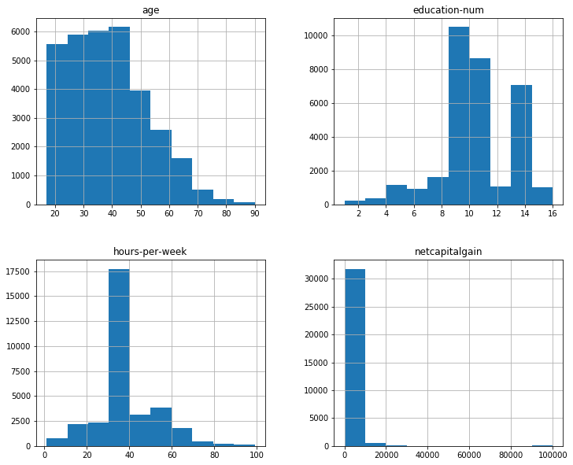

```python
# histogram
data.hist(figsize=(12,10));
```

The visualization of the numerical attributes gives insights on the distribution of values.

- Most individuals are age < 50 with max age around 90.
- Most people have an education number 9, 10, 14 years
- Most of the people work around 40 hrs per week. However there are a few who don't work and a few who work for almost 100 hours a week.
- vast majority have few capital gains, but there are some outliers. Histogram is skewed right (eg: mean > median)

### Density Plot (Univariate)

- applies to numeric values
- similiar to histogram but smoothed

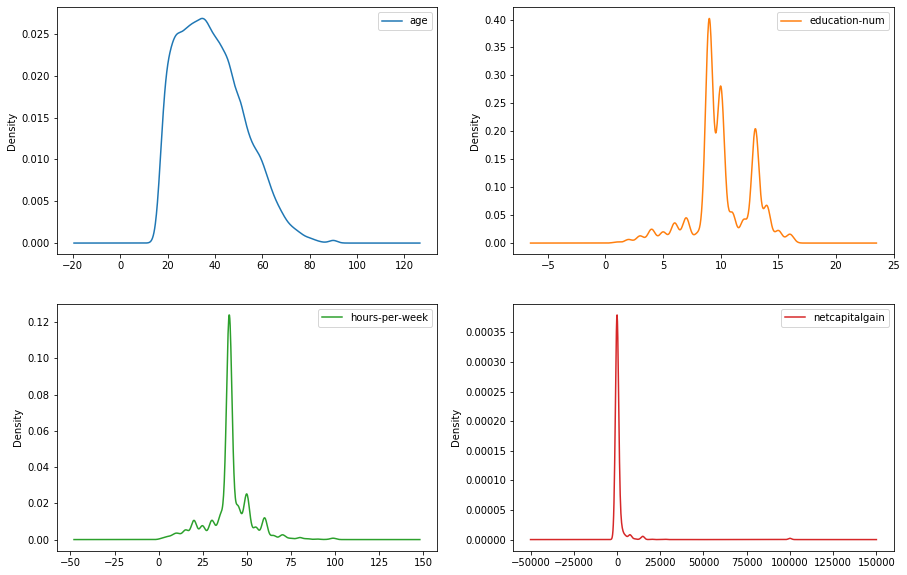

```python
data.plot(figsize=(15,10), kind='density', subplots=True,
          layout=(2,2),
          sharex=False);
```

### Box plots for numerical values (Univariate)

- useful to show distribution (skewness, outliers)

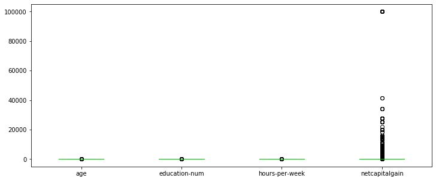

```python
data.plot(figsize=(12,5), kind='box');
```

The boxplots on a single figure is very hard to see due to difference in numeric scales, in particular due to netcapitalgain. Next we use the seaborn library to plot each

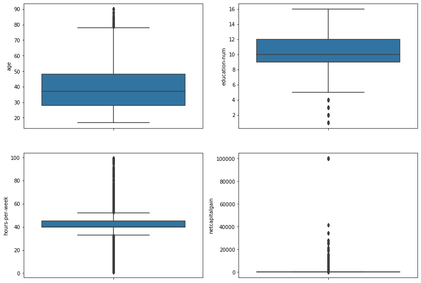

```python
# using seaborn library, plot each individually
fig, axes = plt.subplots(2, 2, figsize=(14,10))

ax = sns.boxplot(data['age'], orient='v', ax=axes[0, 0])
ax = sns.boxplot(data['education-num'], orient='v', ax=axes[0, 1])
ax = sns.boxplot(data['hours-per-week'], orient='v', ax=axes[1, 0])
ax = sns.boxplot(data['netcapitalgain'], orient='v',  ax=axes[1, 1])
```

## Plots for categorical data (Univariate)

- count plots showing counts by category
- boxplot showing distribution by category

```python
# show columns for categorical dataset created earlier
cat_data.columns
```

```
Index(['work-class', 'education', 'marital-status', 'occupation',
       'relationship', 'race', 'sex', 'native-country', 'income'],
      dtype='object')
```

### Plots for work class

- this is an example of plots for categorical data, using seaborn libary

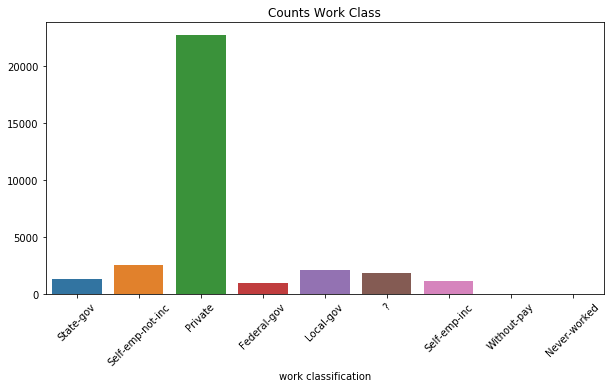

```python
plt.figure(figsize=(10,5))
ax=sns.countplot(data = cat_data, x = "work-class")
ax.set_title('Counts Work Class')
plt.xticks(rotation=45)
ax.set(xlabel='work classification', ylabel='');
```

Most people in the dataset work in private sectors, with near even distributed among rest. There is some unknown sector designated by ?

## Explore the relationships among various attributes

- Cross tabulations/contingency tables
- Multivariate plots
- Correlation heatmaps

We will plot pair plot to explore the pairwise relationship among attributes.

- The diagonal shows histograms of each attribute (this is the default). You can specify a different value (eg: diagonal='kde') such as Kernel density estimation
- In the other cells are the scatterplots (i.e. correlation plot) of each variable combination

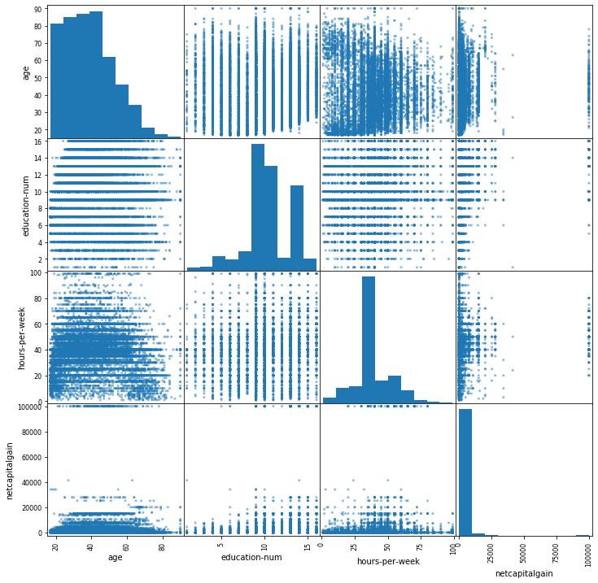

```python
from pandas.plotting import scatter_matrix

scatter_matrix(data, figsize=(12, 12));
```

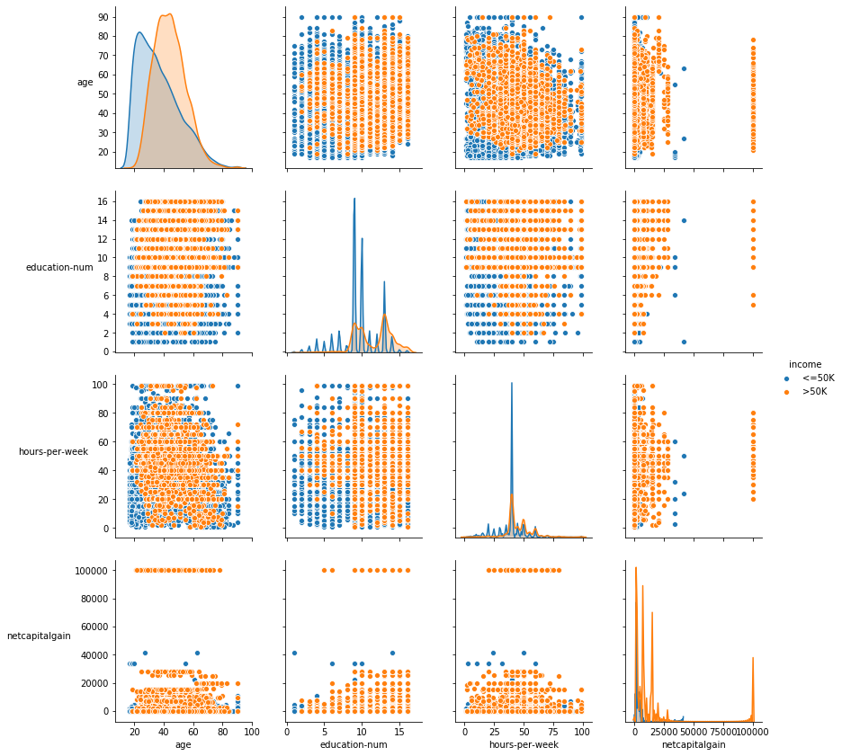

```python
# Using seaborn, pairwise plot by income

g=sns.pairplot(data, diag_kind = 'kde', hue='income')
g.fig.set_size_inches(12,12);

# rotate labels
for ax in g.axes.flatten():
    # rotate y axis labels
    ax.set_ylabel(ax.get_ylabel(), rotation = 0)
    # set y labels alignment
    ax.yaxis.get_label().set_horizontalalignment('right')
```

From the scatter plots, there looks to be little correlation between the variables

### Correlation Analysis

Correlation is the statistical summary of the relationship between variables

- Pearson's correlation for continuous values
  - Pearson correlation coefficient used to summarize the strength of the linear relationship between 2 data samples
  - value between -1 and 1 (full negative correlation to a full positive correlation), 0 means no correlation.
  - value below -0.5 or above 0.5 suggests a strong correlation; values below suggest weak correlation

```python
# Compute the correlation matrix
corr = data.corr()
corr.style.background_gradient(cmap='coolwarm')
```

|  | age | education-num | hours-per-week | netcapitalgain |
| --- | --- | --- | --- | --- |
| age | 1.000000 | 0.036224 | 0.068515 | 0.080846 |
| education-num | 0.036224 | 1.000000 | 0.148422 | 0.127053 |
| hours-per-week | 0.068515 | 0.148422 | 1.000000 | 0.081386 |
| netcapitalgain | 0.080846 | 0.127053 | 0.081386 | 1.000000 |

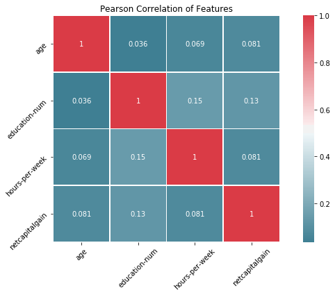

```python
# using seaboarn to plot correlation heat map

f, ax = plt.subplots(figsize=(12, 6))

# generate a custom diverging colormap
cmap = sns.diverging_palette(220,10, as_cmap=True)

sns.heatmap(corr, cmap=cmap, annot=True, square=True, ax=ax,  linewidth = 0.1)
plt.title('Pearson Correlation of Features')
plt.yticks(rotation=45)
plt.xticks(rotation=45);
```

Correlation analysis is important for linear regression models. Here we decide on the prediction target (Eg: outcome or dependent variable) and what input features (predictor or independent variables) contribute to the prediction. We choose variables with the highest correlation between it and the target. If 2 predictor variables are also correlated (multicolinarity), we can decise to remove one of them.

- not very strong correlations between the numeric features.
- education-num: the strongest (+) correlation is between hours-per-week, net-capital-gains

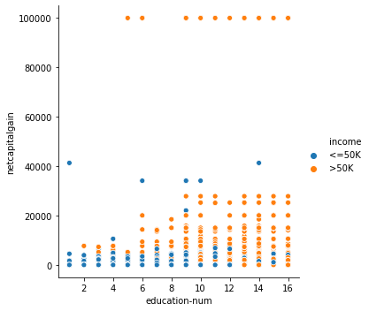

```python
# scatter plots

sns.relplot(x="education-num", y="netcapitalgain", hue='income', data=data);
```

- most people don't earn much capital gains, while higher incomes (> 50K) tend to have higher captical gains with a numer of outliers at the extreme case (100K) and these tend to be higher income folks also. There is a slight linear relationship between capital gains and eduction level

```python
# Cross tabulation between work-class and sex

pd.crosstab(data['work-class'],data['sex'], margins=True)
```

| sex work-class | Female | Male | All |
| --- | --- | --- | --- |
| ? | 839 | 997 | 1836 |
| Federal-gov | 315 | 645 | 960 |
| Local-gov | 835 | 1258 | 2093 |
| Never-worked | 2 | 5 | 7 |
| Private | 7743 | 14930 | 22673 |
| Self-emp-inc | 135 | 981 | 1116 |
| Self-emp-not-inc | 399 | 2141 | 2540 |
| State-gov | 489 | 809 | 1298 |
| Without-pay | 5 | 9 | 14 |
| All | 10762 | 21775 | 32537 |

- we can see the dataset contains about half as many females vs males
- more males are self employed vs females

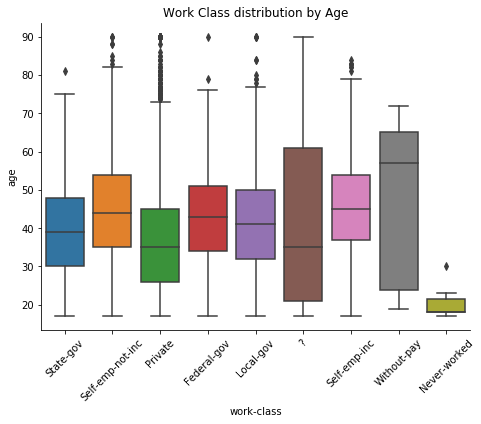

```python
# Distributions of observations within categories
sns.catplot(x="work-class", y="age", kind="box", data=data,
           height=5, aspect=11/8)
plt.title('Work Class distribution by Age')
plt.xticks(rotation=45);
```

Average working age is around 30-40 where-as those under the age of 20 never worked. Working without pay (eg: volunteering) tends to be in older adults past 50.

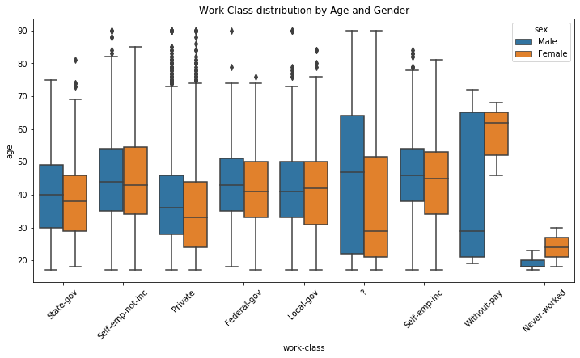

```python
# Box plot between work-class and age for different sex

plt.figure(figsize=(12,6))
sns.boxplot(x="work-class",y="age", hue="sex", data=data)
plt.title('Work Class distribution by Age and Gender')
plt.xticks(rotation=45);
```

- people who have never worked are younger age, with women having a higher median age than men
- men working without pay have a median age around 30, whereas women have a median age of around 65
- most people who work have a median age of around 40-50

**Education vs Income**

```python
data['income'].value_counts()
```

```
<=50K    24698
>50K      7839
Name: income, dtype: int64
```

```python
low = len(data[data['income'] == '<=50K']) / len(data)
high = len(data[data['income'] == '>50K']) / len(data)
print(f'<=50K: {round(low, 2)}  >50K {round(high, 2)}')
```

```
<=50K: 0.76  >50K 0.24
```

Over 75% of the dataset constitutes those earning <= 50K

```python
data['education'].value_counts()
```

```
HS-grad         10494
Some-college     9731
Bachelors        5353
LessHS           4248
Masters          2298
Doctorate         413
Name: education, dtype: int64
```

majority are HS grades, followed by some college, then bachelors

```python
# cross tab as percentages
pd.crosstab(data['education'],data['income'], margins=True, normalize='index')
```

| income education | <=50K | >50K |
| --- | --- | --- |
| Bachelors | 0.585092 | 0.414908 |
| Doctorate | 0.259080 | 0.740920 |
| HS-grad | 0.840480 | 0.159520 |
| LessHS | 0.942561 | 0.057439 |
| Masters | 0.398607 | 0.601393 |
| Some-college | 0.793238 | 0.206762 |
| All | 0.759074 | 0.240926 |

- the contingency table reveals that as education level increases, so too (in general), does income.
- we see that graduate and post-graduate has a substantial increase in income
- less than HS and those with only HS earn the least
- on the other hand, it may be surprising to see that income levels aren't higher with respect to BS, however one must factor in industry and occupation. For example, teaching or public sector employment will not pay as much

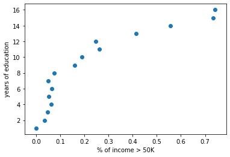

```python
# datafrom cross tab
df = pd.crosstab(data['education-num'],data['income'], margins=True, normalize='index')
df = df[:-1] # exclude last row (All)

# scatter plot
Y=df.index
X=df['>50K']

plt.scatter(X, Y, marker='o');
plt.xlabel('% of income > 50K')
plt.ylabel('years of education');
```

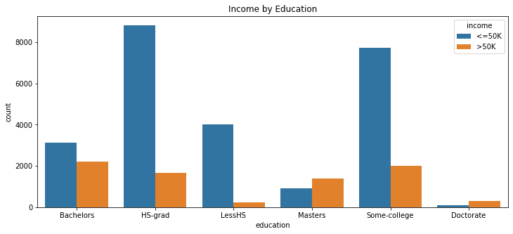

```python
fig = plt.figure(figsize=(12,5))
ax=sns.countplot(x="education", hue="income", data=data)
ax.set_title('Income by Education');
```

Higher education level generally results in higher income